# R Notebook

# Metadata

### Student: Kyler Halat-Shafer

### User ID: uxt5qb

This salesperson has a quarterly quota of $225,000.

The payment received follows a progressive schedule with four brackets as follows:

For the first 40% of quota, the salesperson receives 7% on quota reached For the next 30% of quota, the salesperson receives 10% on quota reached For the next 20% of quota, the salesperson receives 13% on quota reached For the next 10% of quota, the salesperson receives 16% on quota reached

### Understanding the problem

Tier 1 -- (225,000 *.40* .07) this is between 0 and 40%: up until 90,000 Tier 2 -- (225,000 * .30 * .10) this is between 41% and 70%: 90,001 to 157,500 Tier 3 -- (225,000 * .20 * .13) this is between 71% and 90% : 157,501 to 202,500 Tier 4 -- (225,000 * .10 *.16) this is between 91% and 100% : 202,501 to 225,000

Ignoring sales above 225,000

### Quota function for Task 1

#### I used if and else if statements to build on one another to compute the amount that is subscribed to each bracket

```r
quotafn <- function(n){
  quota <- 225000
  if (n <= 0.40) {
     (quota * n * .07)
  }
  else if (n > 0.40 & n <= .70){
    ((n-.4)*quota *.1) + (.4*quota*.07)
  }
  else if (n > .70 & n <= .90){
    ((n - .7)*quota*.13) + (.3 * quota * .10) + (.4 * quota * .07)
  }
  else if (n > .90 & n<= 1){
    ((n-.9)*quota*.16) + (.2 * quota * .13) + (.3 * quota * .10) + (.4 * quota * .07)
  }
}
```

```r
quotafn(n=.8)
```

```
[1] 15975
```

```r
quotafn(n=.6)
```

```
[1] 10800
```

### Task 2

#### When I used the range and the seq functions (I had classified the start, stop and step), it did not match the output that I was expecting it to. This could have been done using a for loop / list comprehension to iterate from 0 to 1 by .1, for x in quotafn(x) as well.

```r
y <- c(quotafn(0),quotafn(.1),quotafn(.2),quotafn(.3),quotafn(.4),quotafn(.5),quotafn(.6),quotafn(.7),quotafn(.8),quotafn(.9),quotafn(1))
y
```

```
 [1]     0  1575  3150  4725  6300  8550 10800 13050 15975 18900 22500
```

```r
x <- c(0,.1,.2,.3,.4,.5,.6,.7,.8,.9,1)
x
```

```
 [1] 0.0 0.1 0.2 0.3 0.4 0.5 0.6 0.7 0.8 0.9 1.0
```

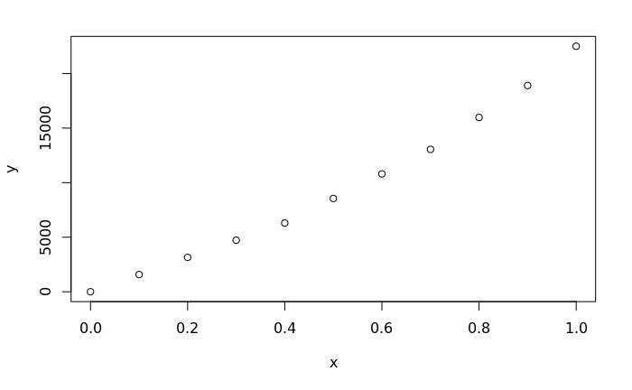

```r
plot(x,y)
```

```r
quotafn(1)
```

```
[1] 22500
```

Manual n at .8 check ... 6,300 + 6,750 + 2,925 = 15,975 Mannual check for 1, 6,300 + 6,750 + 5,850 + 3,600 = 22,500